# Risk Factor Analysis

## Outcome Variable

**Outcome Variable:** ever_sstunted

## Predictor Variables

**Intervention Variable:** single

**Adjustment Set:**

- arm
- W_mage
- meducyrs
- feducyrs
- W_mhtcm
- W_mwtkg
- W_mbmi
- delta_W_mage
- delta_meducyrs
- delta_feducyrs
- delta_W_mhtcm
- delta_W_mwtkg
- delta_W_mbmi

## Stratifying Variables

The analysis was stratified on these variable(s):

- agecat
- studyid
- country

## Data Summary

| agecat | studyid | country | single | ever_sstunted | n_cell | n |
| --- | --- | --- | --- | --- | --- | --- |
| 0-24 months | ki0047075b-MAL-ED | BANGLADESH | 0 | 0 | 208 | 265 |
| 0-24 months | ki0047075b-MAL-ED | BANGLADESH | 0 | 1 | 57 | 265 |
| 0-24 months | ki0047075b-MAL-ED | BANGLADESH | 1 | 0 | 0 | 265 |
| 0-24 months | ki0047075b-MAL-ED | BANGLADESH | 1 | 1 | 0 | 265 |
| 0-24 months | ki0047075b-MAL-ED | BRAZIL | 0 | 0 | 186 | 233 |
| 0-24 months | ki0047075b-MAL-ED | BRAZIL | 0 | 1 | 11 | 233 |
| 0-24 months | ki0047075b-MAL-ED | BRAZIL | 1 | 0 | 29 | 233 |
| 0-24 months | ki0047075b-MAL-ED | BRAZIL | 1 | 1 | 7 | 233 |
| 0-24 months | ki0047075b-MAL-ED | INDIA | 0 | 0 | 195 | 249 |
| 0-24 months | ki0047075b-MAL-ED | INDIA | 0 | 1 | 54 | 249 |
| 0-24 months | ki0047075b-MAL-ED | INDIA | 1 | 0 | 0 | 249 |
| 0-24 months | ki0047075b-MAL-ED | INDIA | 1 | 1 | 0 | 249 |
| 0-24 months | ki0047075b-MAL-ED | NEPAL | 0 | 0 | 219 | 240 |
| 0-24 months | ki0047075b-MAL-ED | NEPAL | 0 | 1 | 21 | 240 |
| 0-24 months | ki0047075b-MAL-ED | NEPAL | 1 | 0 | 0 | 240 |
| 0-24 months | ki0047075b-MAL-ED | NEPAL | 1 | 1 | 0 | 240 |
| 0-24 months | ki0047075b-MAL-ED | PERU | 0 | 0 | 214 | 303 |
| 0-24 months | ki0047075b-MAL-ED | PERU | 0 | 1 | 54 | 303 |
| 0-24 months | ki0047075b-MAL-ED | PERU | 1 | 0 | 25 | 303 |
| 0-24 months | ki0047075b-MAL-ED | PERU | 1 | 1 | 10 | 303 |
| 0-24 months | ki0047075b-MAL-ED | SOUTH AFRICA | 0 | 0 | 139 | 314 |
| 0-24 months | ki0047075b-MAL-ED | SOUTH AFRICA | 0 | 1 | 37 | 314 |
| 0-24 months | ki0047075b-MAL-ED | SOUTH AFRICA | 1 | 0 | 103 | 314 |
| 0-24 months | ki0047075b-MAL-ED | SOUTH AFRICA | 1 | 1 | 35 | 314 |
| 0-24 months | ki0047075b-MAL-ED | TANZANIA, UNITED REPUBLIC OF | 0 | 0 | 120 | 262 |
| 0-24 months | ki0047075b-MAL-ED | TANZANIA, UNITED REPUBLIC OF | 0 | 1 | 132 | 262 |
| 0-24 months | ki0047075b-MAL-ED | TANZANIA, UNITED REPUBLIC OF | 1 | 0 | 7 | 262 |
| 0-24 months | ki0047075b-MAL-ED | TANZANIA, UNITED REPUBLIC OF | 1 | 1 | 3 | 262 |
| 0-24 months | ki1066203-TanzaniaChild2 | TANZANIA, UNITED REPUBLIC OF | 0 | 0 | 1933 | 2375 |
| 0-24 months | ki1066203-TanzaniaChild2 | TANZANIA, UNITED REPUBLIC OF | 0 | 1 | 218 | 2375 |

[output cut: 82 more lines]

The following strata were considered:

- agecat: 0-24 months, studyid: ki0047075b-MAL-ED, country: BANGLADESH
- agecat: 0-24 months, studyid: ki0047075b-MAL-ED, country: BRAZIL
- agecat: 0-24 months, studyid: ki0047075b-MAL-ED, country: INDIA
- agecat: 0-24 months, studyid: ki0047075b-MAL-ED, country: NEPAL
- agecat: 0-24 months, studyid: ki0047075b-MAL-ED, country: PERU
- agecat: 0-24 months, studyid: ki0047075b-MAL-ED, country: SOUTH AFRICA
- agecat: 0-24 months, studyid: ki0047075b-MAL-ED, country: TANZANIA, UNITED REPUBLIC OF
- agecat: 0-24 months, studyid: ki1066203-TanzaniaChild2, country: TANZANIA, UNITED REPUBLIC OF
- agecat: 0-24 months, studyid: ki1112895-Guatemala BSC, country: GUATEMALA
- agecat: 0-24 months, studyid: ki1119695-PROBIT, country: BELARUS
- agecat: 0-24 months, studyid: ki1126311-ZVITAMBO, country: ZIMBABWE
- agecat: 0-24 months, studyid: ki1135781-COHORTS, country: GUATEMALA
- agecat: 0-24 months, studyid: ki1135781-COHORTS, country: INDIA
- agecat: 0-24 months, studyid: ki1135781-COHORTS, country: PHILIPPINES
- agecat: 0-6 months, studyid: ki0047075b-MAL-ED, country: BANGLADESH
- agecat: 0-6 months, studyid: ki0047075b-MAL-ED, country: BRAZIL
- agecat: 0-6 months, studyid: ki0047075b-MAL-ED, country: INDIA
- agecat: 0-6 months, studyid: ki0047075b-MAL-ED, country: NEPAL
- agecat: 0-6 months, studyid: ki0047075b-MAL-ED, country: PERU
- agecat: 0-6 months, studyid: ki0047075b-MAL-ED, country: SOUTH AFRICA
- agecat: 0-6 months, studyid: ki0047075b-MAL-ED, country: TANZANIA, UNITED REPUBLIC OF
- agecat: 0-6 months, studyid: ki1066203-TanzaniaChild2, country: TANZANIA, UNITED REPUBLIC OF
- agecat: 0-6 months, studyid: ki1112895-Guatemala BSC, country: GUATEMALA
- agecat: 0-6 months, studyid: ki1119695-PROBIT, country: BELARUS
- agecat: 0-6 months, studyid: ki1126311-ZVITAMBO, country: ZIMBABWE
- agecat: 0-6 months, studyid: ki1135781-COHORTS, country: GUATEMALA
- agecat: 0-6 months, studyid: ki1135781-COHORTS, country: INDIA
- agecat: 0-6 months, studyid: ki1135781-COHORTS, country: PHILIPPINES

### Dropped Strata

Some strata were dropped due to rare outcomes:

- agecat: 0-24 months, studyid: ki0047075b-MAL-ED, country: BANGLADESH
- agecat: 0-24 months, studyid: ki0047075b-MAL-ED, country: INDIA
- agecat: 0-24 months, studyid: ki0047075b-MAL-ED, country: NEPAL
- agecat: 0-24 months, studyid: ki0047075b-MAL-ED, country: TANZANIA, UNITED REPUBLIC OF
- agecat: 0-24 months, studyid: ki1135781-COHORTS, country: INDIA
- agecat: 0-6 months, studyid: ki0047075b-MAL-ED, country: BANGLADESH
- agecat: 0-6 months, studyid: ki0047075b-MAL-ED, country: INDIA
- agecat: 0-6 months, studyid: ki0047075b-MAL-ED, country: NEPAL
- agecat: 0-6 months, studyid: ki0047075b-MAL-ED, country: TANZANIA, UNITED REPUBLIC OF
- agecat: 0-6 months, studyid: ki1135781-COHORTS, country: INDIA

## Methods Detail

We’re interested in the causal parameters $E[Y_a]$ for all values of $a \in \mathcal{A}$. These parameters represent the mean outcome if, possibly contrary to fact, we intervened to set all units to have $A=a$. Under the randomization and positivity assumptions, these are identified by the statistical parameters $\psi_a=E_W[E_{Y|A,W}(Y|A=a,W)]$. In addition, we’re interested in the mean of $Y$, $E[Y]$ under no intervention (the observed mean). We will estimate these parameters by using SuperLearner to fit the relevant likelihood factors – $E_{Y|A,W}(Y|A=a,W)$ and $p(A=a|W)$, and then updating our likelihood fit using a joint TMLE.

For unadjusted analyses ($W=\{\}$), initial likelihoods were estimated using Lrnr_glm to estimate the simple $E(Y|A)$ and Lrnr_mean to estimate $p(A)$. For adjusted analyses, a small library containing Lrnr_glmnet, Lrnr_xgboost, and Lrnr_mean was used.

Having estimated these parameters, we will then use the delta method to estimate relative risks and attributable risks relative to a prespecified baseline level of $A$.

# Results Detail

## Results Plots

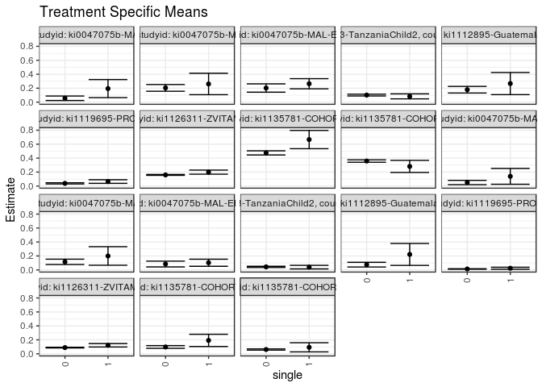

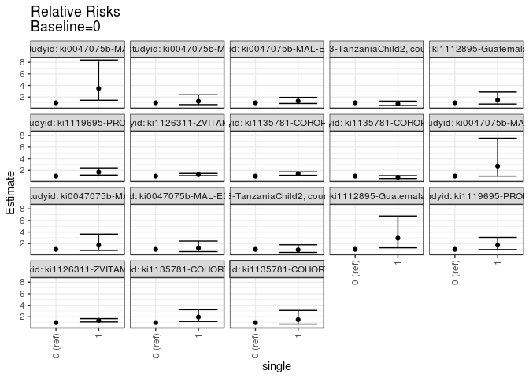

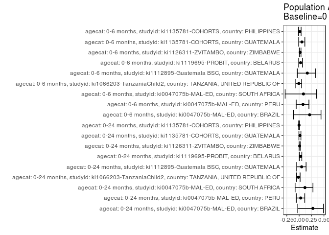

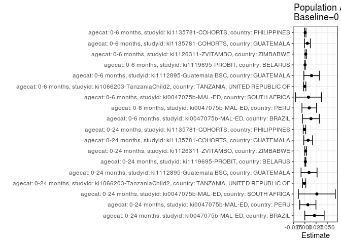

## Results Table

### Parameter: TSM

| agecat | studyid | country | intervention_level | baseline_level | estimate | ci_lower | ci_upper |
| --- | --- | --- | --- | --- | --- | --- | --- |
| 0-24 months | ki0047075b-MAL-ED | BRAZIL | 0 | NA | 0.0558376 | 0.0237057 | 0.0879694 |
| 0-24 months | ki0047075b-MAL-ED | BRAZIL | 1 | NA | 0.1944444 | 0.0648828 | 0.3240061 |
| 0-24 months | ki0047075b-MAL-ED | PERU | 0 | NA | 0.2045944 | 0.1562861 | 0.2529027 |
| 0-24 months | ki0047075b-MAL-ED | PERU | 1 | NA | 0.2605797 | 0.1071774 | 0.4139820 |
| 0-24 months | ki0047075b-MAL-ED | SOUTH AFRICA | 0 | NA | 0.2025775 | 0.1428499 | 0.2623052 |
| 0-24 months | ki0047075b-MAL-ED | SOUTH AFRICA | 1 | NA | 0.2637946 | 0.1911011 | 0.3364880 |
| 0-24 months | ki1066203-TanzaniaChild2 | TANZANIA, UNITED REPUBLIC OF | 0 | NA | 0.1013822 | 0.0886293 | 0.1141351 |
| 0-24 months | ki1066203-TanzaniaChild2 | TANZANIA, UNITED REPUBLIC OF | 1 | NA | 0.0830389 | 0.0470302 | 0.1190476 |
| 0-24 months | ki1112895-Guatemala BSC | GUATEMALA | 0 | NA | 0.1785714 | 0.1312007 | 0.2259422 |
| 0-24 months | ki1112895-Guatemala BSC | GUATEMALA | 1 | NA | 0.2666667 | 0.1081431 | 0.4251903 |
| 0-24 months | ki1119695-PROBIT | BELARUS | 0 | NA | 0.0382806 | 0.0299913 | 0.0465699 |
| 0-24 months | ki1119695-PROBIT | BELARUS | 1 | NA | 0.0644722 | 0.0385777 | 0.0903667 |
| 0-24 months | ki1126311-ZVITAMBO | ZIMBABWE | 0 | NA | 0.1593413 | 0.1530466 | 0.1656360 |
| 0-24 months | ki1126311-ZVITAMBO | ZIMBABWE | 1 | NA | 0.1993580 | 0.1699676 | 0.2287485 |
| 0-24 months | ki1135781-COHORTS | GUATEMALA | 0 | NA | 0.4749235 | 0.4452579 | 0.5045891 |
| 0-24 months | ki1135781-COHORTS | GUATEMALA | 1 | NA | 0.6659280 | 0.5348622 | 0.7969937 |
| 0-24 months | ki1135781-COHORTS | PHILIPPINES | 0 | NA | 0.3583856 | 0.3409564 | 0.3758149 |
| 0-24 months | ki1135781-COHORTS | PHILIPPINES | 1 | NA | 0.2813660 | 0.1946441 | 0.3680880 |
| 0-6 months | ki0047075b-MAL-ED | BRAZIL | 0 | NA | 0.0507614 | 0.0200427 | 0.0814802 |
| 0-6 months | ki0047075b-MAL-ED | BRAZIL | 1 | NA | 0.1388889 | 0.0256764 | 0.2521013 |
| 0-6 months | ki0047075b-MAL-ED | PERU | 0 | NA | 0.1156716 | 0.0773169 | 0.1540264 |
| 0-6 months | ki0047075b-MAL-ED | PERU | 1 | NA | 0.2000000 | 0.0672630 | 0.3327370 |
| 0-6 months | ki0047075b-MAL-ED | SOUTH AFRICA | 0 | NA | 0.0843453 | 0.0429375 | 0.1257531 |
| 0-6 months | ki0047075b-MAL-ED | SOUTH AFRICA | 1 | NA | 0.1031074 | 0.0523429 | 0.1538720 |
| 0-6 months | ki1066203-TanzaniaChild2 | TANZANIA, UNITED REPUBLIC OF | 0 | NA | 0.0437006 | 0.0350597 | 0.0523415 |
| 0-6 months | ki1066203-TanzaniaChild2 | TANZANIA, UNITED REPUBLIC OF | 1 | NA | 0.0401786 | 0.0144564 | 0.0659008 |
| 0-6 months | ki1112895-Guatemala BSC | GUATEMALA | 0 | NA | 0.0756303 | 0.0419751 | 0.1092854 |
| 0-6 months | ki1112895-Guatemala BSC | GUATEMALA | 1 | NA | 0.2222222 | 0.0651105 | 0.3793340 |
| 0-6 months | ki1119695-PROBIT | BELARUS | 0 | NA | 0.0137890 | 0.0104299 | 0.0171482 |
| 0-6 months | ki1119695-PROBIT | BELARUS | 1 | NA | 0.0236807 | 0.0089359 | 0.0384256 |
| 0-6 months | ki1126311-ZVITAMBO | ZIMBABWE | 0 | NA | 0.0890051 | 0.0841130 | 0.0938972 |
| 0-6 months | ki1126311-ZVITAMBO | ZIMBABWE | 1 | NA | 0.1221882 | 0.0976409 | 0.1467355 |
| 0-6 months | ki1135781-COHORTS | GUATEMALA | 0 | NA | 0.0980275 | 0.0786264 | 0.1174286 |
| 0-6 months | ki1135781-COHORTS | GUATEMALA | 1 | NA | 0.1920361 | 0.1042470 | 0.2798253 |
| 0-6 months | ki1135781-COHORTS | PHILIPPINES | 0 | NA | 0.0615019 | 0.0528192 | 0.0701845 |
| 0-6 months | ki1135781-COHORTS | PHILIPPINES | 1 | NA | 0.0933333 | 0.0278797 | 0.1587870 |

### Parameter: E(Y)

| agecat | studyid | country | intervention_level | baseline_level | estimate | ci_lower | ci_upper |
| --- | --- | --- | --- | --- | --- | --- | --- |
| 0-24 months | ki0047075b-MAL-ED | BRAZIL | NA | NA | 0.0772532 | 0.0428971 | 0.1116093 |
| 0-24 months | ki0047075b-MAL-ED | PERU | NA | NA | 0.2112211 | 0.1651858 | 0.2572564 |
| 0-24 months | ki0047075b-MAL-ED | SOUTH AFRICA | NA | NA | 0.2292994 | 0.1827279 | 0.2758709 |
| 0-24 months | ki1066203-TanzaniaChild2 | TANZANIA, UNITED REPUBLIC OF | NA | NA | 0.0997895 | 0.0877329 | 0.1118460 |
| 0-24 months | ki1112895-Guatemala BSC | GUATEMALA | NA | NA | 0.1879433 | 0.1422658 | 0.2336207 |
| 0-24 months | ki1119695-PROBIT | BELARUS | NA | NA | 0.0394153 | 0.0310085 | 0.0478221 |
| 0-24 months | ki1126311-ZVITAMBO | ZIMBABWE | NA | NA | 0.1609704 | 0.1548858 | 0.1670549 |
| 0-24 months | ki1135781-COHORTS | GUATEMALA | NA | NA | 0.4821872 | 0.4539860 | 0.5103885 |
| 0-24 months | ki1135781-COHORTS | PHILIPPINES | NA | NA | 0.3575215 | 0.3404198 | 0.3746233 |
| 0-6 months | ki0047075b-MAL-ED | BRAZIL | NA | NA | 0.0643777 | 0.0327970 | 0.0959584 |
| 0-6 months | ki0047075b-MAL-ED | PERU | NA | NA | 0.1254125 | 0.0880603 | 0.1627648 |
| 0-6 months | ki0047075b-MAL-ED | SOUTH AFRICA | NA | NA | 0.0923567 | 0.0602816 | 0.1244318 |
| 0-6 months | ki1066203-TanzaniaChild2 | TANZANIA, UNITED REPUBLIC OF | NA | NA | 0.0433684 | 0.0351750 | 0.0515619 |
| 0-6 months | ki1112895-Guatemala BSC | GUATEMALA | NA | NA | 0.0905660 | 0.0559470 | 0.1251850 |
| 0-6 months | ki1119695-PROBIT | BELARUS | NA | NA | 0.0142071 | 0.0107237 | 0.0176904 |
| 0-6 months | ki1126311-ZVITAMBO | ZIMBABWE | NA | NA | 0.0909026 | 0.0861394 | 0.0956658 |
| 0-6 months | ki1135781-COHORTS | GUATEMALA | NA | NA | 0.1036961 | 0.0845403 | 0.1228519 |
| 0-6 months | ki1135781-COHORTS | PHILIPPINES | NA | NA | 0.0622929 | 0.0536688 | 0.0709170 |

### Parameter: RR

| agecat | studyid | country | intervention_level | baseline_level | estimate | ci_lower | ci_upper |
| --- | --- | --- | --- | --- | --- | --- | --- |
| 0-24 months | ki0047075b-MAL-ED | BRAZIL | 0 | 0 | 1.0000000 | 1.0000000 | 1.000000 |
| 0-24 months | ki0047075b-MAL-ED | BRAZIL | 1 | 0 | 3.4823232 | 1.4438150 | 8.398981 |
| 0-24 months | ki0047075b-MAL-ED | PERU | 0 | 0 | 1.0000000 | 1.0000000 | 1.000000 |
| 0-24 months | ki0047075b-MAL-ED | PERU | 1 | 0 | 1.2736403 | 0.6774579 | 2.394480 |
| 0-24 months | ki0047075b-MAL-ED | SOUTH AFRICA | 0 | 0 | 1.0000000 | 1.0000000 | 1.000000 |
| 0-24 months | ki0047075b-MAL-ED | SOUTH AFRICA | 1 | 0 | 1.3021906 | 0.8747624 | 1.938470 |
| 0-24 months | ki1066203-TanzaniaChild2 | TANZANIA, UNITED REPUBLIC OF | 0 | 0 | 1.0000000 | 1.0000000 | 1.000000 |
| 0-24 months | ki1066203-TanzaniaChild2 | TANZANIA, UNITED REPUBLIC OF | 1 | 0 | 0.8190677 | 0.5218957 | 1.285452 |
| 0-24 months | ki1112895-Guatemala BSC | GUATEMALA | 0 | 0 | 1.0000000 | 1.0000000 | 1.000000 |
| 0-24 months | ki1112895-Guatemala BSC | GUATEMALA | 1 | 0 | 1.4933333 | 0.7788347 | 2.863309 |
| 0-24 months | ki1119695-PROBIT | BELARUS | 0 | 0 | 1.0000000 | 1.0000000 | 1.000000 |
| 0-24 months | ki1119695-PROBIT | BELARUS | 1 | 0 | 1.6842003 | 1.1719459 | 2.420360 |
| 0-24 months | ki1126311-ZVITAMBO | ZIMBABWE | 0 | 0 | 1.0000000 | 1.0000000 | 1.000000 |
| 0-24 months | ki1126311-ZVITAMBO | ZIMBABWE | 1 | 0 | 1.2511387 | 1.0742444 | 1.457162 |
| 0-24 months | ki1135781-COHORTS | GUATEMALA | 0 | 0 | 1.0000000 | 1.0000000 | 1.000000 |
| 0-24 months | ki1135781-COHORTS | GUATEMALA | 1 | 0 | 1.4021794 | 1.1406031 | 1.723743 |
| 0-24 months | ki1135781-COHORTS | PHILIPPINES | 0 | 0 | 1.0000000 | 1.0000000 | 1.000000 |
| 0-24 months | ki1135781-COHORTS | PHILIPPINES | 1 | 0 | 0.7850929 | 0.5746573 | 1.072588 |
| 0-6 months | ki0047075b-MAL-ED | BRAZIL | 0 | 0 | 1.0000000 | 1.0000000 | 1.000000 |
| 0-6 months | ki0047075b-MAL-ED | BRAZIL | 1 | 0 | 2.7361111 | 0.9913638 | 7.551521 |
| 0-6 months | ki0047075b-MAL-ED | PERU | 0 | 0 | 1.0000000 | 1.0000000 | 1.000000 |
| 0-6 months | ki0047075b-MAL-ED | PERU | 1 | 0 | 1.7290323 | 0.8233744 | 3.630854 |
| 0-6 months | ki0047075b-MAL-ED | SOUTH AFRICA | 0 | 0 | 1.0000000 | 1.0000000 | 1.000000 |
| 0-6 months | ki0047075b-MAL-ED | SOUTH AFRICA | 1 | 0 | 1.2224443 | 0.6112557 | 2.444755 |
| 0-6 months | ki1066203-TanzaniaChild2 | TANZANIA, UNITED REPUBLIC OF | 0 | 0 | 1.0000000 | 1.0000000 | 1.000000 |
| 0-6 months | ki1066203-TanzaniaChild2 | TANZANIA, UNITED REPUBLIC OF | 1 | 0 | 0.9194054 | 0.4704504 | 1.796802 |
| 0-6 months | ki1112895-Guatemala BSC | GUATEMALA | 0 | 0 | 1.0000000 | 1.0000000 | 1.000000 |
| 0-6 months | ki1112895-Guatemala BSC | GUATEMALA | 1 | 0 | 2.9382716 | 1.2743457 | 6.774802 |
| 0-6 months | ki1119695-PROBIT | BELARUS | 0 | 0 | 1.0000000 | 1.0000000 | 1.000000 |
| 0-6 months | ki1119695-PROBIT | BELARUS | 1 | 0 | 1.7173603 | 0.9641389 | 3.059026 |
| 0-6 months | ki1126311-ZVITAMBO | ZIMBABWE | 0 | 0 | 1.0000000 | 1.0000000 | 1.000000 |
| 0-6 months | ki1126311-ZVITAMBO | ZIMBABWE | 1 | 0 | 1.3728214 | 1.1147991 | 1.690563 |
| 0-6 months | ki1135781-COHORTS | GUATEMALA | 0 | 0 | 1.0000000 | 1.0000000 | 1.000000 |
| 0-6 months | ki1135781-COHORTS | GUATEMALA | 1 | 0 | 1.9590025 | 1.1924982 | 3.218194 |
| 0-6 months | ki1135781-COHORTS | PHILIPPINES | 0 | 0 | 1.0000000 | 1.0000000 | 1.000000 |
| 0-6 months | ki1135781-COHORTS | PHILIPPINES | 1 | 0 | 1.5175691 | 0.7421172 | 3.103305 |

### Parameter: PAR

| agecat | studyid | country | intervention_level | baseline_level | estimate | ci_lower | ci_upper |
| --- | --- | --- | --- | --- | --- | --- | --- |
| 0-24 months | ki0047075b-MAL-ED | BRAZIL | 0 | NA | 0.0214157 | -0.0001929 | 0.0430242 |
| 0-24 months | ki0047075b-MAL-ED | PERU | 0 | NA | 0.0066267 | -0.0114021 | 0.0246555 |
| 0-24 months | ki0047075b-MAL-ED | SOUTH AFRICA | 0 | NA | 0.0267218 | -0.0144244 | 0.0678681 |
| 0-24 months | ki1066203-TanzaniaChild2 | TANZANIA, UNITED REPUBLIC OF | 0 | NA | -0.0015927 | -0.0051818 | 0.0019963 |
| 0-24 months | ki1112895-Guatemala BSC | GUATEMALA | 0 | NA | 0.0093718 | -0.0085135 | 0.0272571 |
| 0-24 months | ki1119695-PROBIT | BELARUS | 0 | NA | 0.0011347 | 0.0001325 | 0.0021369 |
| 0-24 months | ki1126311-ZVITAMBO | ZIMBABWE | 0 | NA | 0.0016291 | -0.0001424 | 0.0034007 |
| 0-24 months | ki1135781-COHORTS | GUATEMALA | 0 | NA | 0.0072637 | -0.0024885 | 0.0170159 |
| 0-24 months | ki1135781-COHORTS | PHILIPPINES | 0 | NA | -0.0008641 | -0.0036659 | 0.0019377 |
| 0-6 months | ki0047075b-MAL-ED | BRAZIL | 0 | NA | 0.0136163 | -0.0049659 | 0.0321985 |
| 0-6 months | ki0047075b-MAL-ED | PERU | 0 | NA | 0.0097409 | -0.0065060 | 0.0259878 |
| 0-6 months | ki0047075b-MAL-ED | SOUTH AFRICA | 0 | NA | 0.0080114 | -0.0207363 | 0.0367591 |
| 0-6 months | ki1066203-TanzaniaChild2 | TANZANIA, UNITED REPUBLIC OF | 0 | NA | -0.0003322 | -0.0028918 | 0.0022274 |
| 0-6 months | ki1112895-Guatemala BSC | GUATEMALA | 0 | NA | 0.0149358 | -0.0022867 | 0.0321583 |
| 0-6 months | ki1119695-PROBIT | BELARUS | 0 | NA | 0.0004180 | -0.0001401 | 0.0009762 |
| 0-6 months | ki1126311-ZVITAMBO | ZIMBABWE | 0 | NA | 0.0018975 | 0.0004685 | 0.0033264 |
| 0-6 months | ki1135781-COHORTS | GUATEMALA | 0 | NA | 0.0056686 | -0.0008303 | 0.0121675 |
| 0-6 months | ki1135781-COHORTS | PHILIPPINES | 0 | NA | 0.0007910 | -0.0008691 | 0.0024512 |

### Parameter: PAF

| agecat | studyid | country | intervention_level | baseline_level | estimate | ci_lower | ci_upper |
| --- | --- | --- | --- | --- | --- | --- | --- |
| 0-24 months | ki0047075b-MAL-ED | BRAZIL | 0 | NA | 0.2772138 | -0.0281511 | 0.4918841 |
| 0-24 months | ki0047075b-MAL-ED | PERU | 0 | NA | 0.0313733 | -0.0576570 | 0.1129093 |
| 0-24 months | ki0047075b-MAL-ED | SOUTH AFRICA | 0 | NA | 0.1165369 | -0.0821132 | 0.2787196 |
| 0-24 months | ki1066203-TanzaniaChild2 | TANZANIA, UNITED REPUBLIC OF | 0 | NA | -0.0159611 | -0.0525231 | 0.0193309 |
| 0-24 months | ki1112895-Guatemala BSC | GUATEMALA | 0 | NA | 0.0498652 | -0.0497480 | 0.1400259 |
| 0-24 months | ki1119695-PROBIT | BELARUS | 0 | NA | 0.0287878 | 0.0033754 | 0.0535522 |
| 0-24 months | ki1126311-ZVITAMBO | ZIMBABWE | 0 | NA | 0.0101206 | -0.0009433 | 0.0210622 |
| 0-24 months | ki1135781-COHORTS | GUATEMALA | 0 | NA | 0.0150641 | -0.0053726 | 0.0350854 |
| 0-24 months | ki1135781-COHORTS | PHILIPPINES | 0 | NA | -0.0024169 | -0.0102809 | 0.0053859 |
| 0-6 months | ki0047075b-MAL-ED | BRAZIL | 0 | NA | 0.2115059 | -0.1126119 | 0.4412041 |
| 0-6 months | ki0047075b-MAL-ED | PERU | 0 | NA | 0.0776709 | -0.0596587 | 0.1972028 |
| 0-6 months | ki0047075b-MAL-ED | SOUTH AFRICA | 0 | NA | 0.0867440 | -0.2829649 | 0.3499147 |
| 0-6 months | ki1066203-TanzaniaChild2 | TANZANIA, UNITED REPUBLIC OF | 0 | NA | -0.0076596 | -0.0684244 | 0.0496494 |
| 0-6 months | ki1112895-Guatemala BSC | GUATEMALA | 0 | NA | 0.1649160 | -0.0375013 | 0.3278415 |
| 0-6 months | ki1119695-PROBIT | BELARUS | 0 | NA | 0.0294240 | -0.0090876 | 0.0664658 |
| 0-6 months | ki1126311-ZVITAMBO | ZIMBABWE | 0 | NA | 0.0208735 | 0.0050536 | 0.0364418 |
| 0-6 months | ki1135781-COHORTS | GUATEMALA | 0 | NA | 0.0546655 | -0.0095777 | 0.1148206 |
| 0-6 months | ki1135781-COHORTS | PHILIPPINES | 0 | NA | 0.0126987 | -0.0142640 | 0.0389447 |